# Markdown Files — My sample book

[figure not shown]

# Tugas 1 : PREDIKSI IKLIM HARIAN DI KUPANG, NUSA TENGGARA TIMUR, INDONESIA MENGGUNAKAN METODE PEMBELAJARAN MESIN BERDASARKAN DATA HISTORIS

## Pendahuluan

### Latar Belakang

Perubahan iklim dan cuaca harian merupakan fenomena yang memiliki dampak signifikan pada berbagai sektor kehidupan, termasuk pertanian, transportasi, kesehatan, dan energi. Data iklim harian, seperti suhu minimum (Tn), suhu maksimum (Tx), suhu rata-rata (Tavg), dan curah hujan (Pr), memainkan peran penting dalam membantu masyarakat dan organisasi untuk memahami pola cuaca dan membuat keputusan yang tepat. Dengan kemajuan teknologi, analisis data dan model prediksi kini memungkinkan kita untuk memperkirakan kondisi cuaca di masa depan berdasarkan data historis.

Dalam konteks ini, kemampuan untuk memprediksi kondisi cuaca harian pada hari berikutnya menjadi sangat penting untuk mengurangi risiko akibat cuaca ekstrem, meningkatkan efisiensi sumber daya, dan memberikan manfaat ekonomi. Dengan mengembangkan model prediksi berbasis data, keputusan strategis dapat dilakukan dengan lebih akurat dan efektif.

### Tujuan Bisnis

1. Prediksi Cuaca Harian yang Akurat: Mengembangkan model prediksi yang dapat memperkirakan suhu minimum, suhu maksimum, suhu rata-rata, dan curah hujan untuk hari berikutnya berdasarkan data historis.
2. Pengambilan Keputusan Strategis: Memberikan informasi prediktif yang berguna bagi pengambil keputusan di sektor pertanian, transportasi, dan energi untuk mengelola risiko dan meningkatkan efisiensi operasional.

### Data Understanding

Dataset ini berisi informasi iklim harian berupa suhu (minimum, maksimum, rata-rata) dan curah hujan untuk rentang waktu tertentu. Data ini akan digunakan untuk membuat model prediksi iklim harian berdasarkan kolom-kolom yang tersedia. Dataset yang digunakan ini berasal dari github berikut link dari dataset tersebut: https://github.com/sandyherho/kupang_rai/blob/main/data/laporan_iklim_harian.csv

Dataset ini memiliki beberapa fitur yaitu :

tanggal: Tipe object (seharusnya diubah menjadi tipe tanggal untuk analisis time-series).

Tn: Tipe float64 (suhu minimum dalam derajat Celsius).

Tx: Tipe float64 (suhu maksimum dalam derajat Celsius).

Tavg: Tipe float64 (suhu rata-rata dalam derajat Celsius).

pr: Tipe float64 (curah hujan dalam milimeter).

Menampilkan jumlah baris dan kolom yang terdapat pada dataset, berikut merupakan cara untuk menampilkan jumlah baris dan kolom:

```python
import numpy as np  # Import library numpy
    import pandas as pd  # Import library pandas
    # Membaca file CSV dari GitHub
    url = "https://raw.githubusercontent.com/Auliyaaas/Proyek-Sains-Data/main/PSD/Iklim%20Harian/iklim_harian.csv"
    df = pd.read_csv(url)  # Membaca file CSV dari URL dan menyimpannya ke dalam DataFrame df
    # Menampilkan bentuk (jumlah baris dan kolom) dari DataFrame df
    df.shape
```

```
(15706, 5)
```

Dari output diatas, dapat disimpulkan bahwa terdapat 15706 baris data dan 5 kolom.

```python
url = "https://raw.githubusercontent.com/Auliyaaas/Proyek-Sains-Data/main/PSD/Iklim%20Harian/iklim_harian.csv"
    df = pd.read_csv(url)
    df.head()
```

|  | tanggal | Tn | Tx | Tavg | pr |
| --- | --- | --- | --- | --- | --- |
| 0 | 01-01-1978 | 24.0 | 32.4 | 28.3 | 0.0 |
| 1 | 02-01-1978 | 24.0 | 31.8 | 28.3 | 8.0 |
| 2 | 03-01-1978 | 24.0 | 30.8 | 26.3 | 26.0 |
| 3 | 04-01-1978 | 23.0 | 30.6 | 26.3 | 21.0 |
| 4 | 05-01-1978 | 25.0 | 30.6 | 27.2 | 1.0 |

### Menentukan Missing Value

```python
import numpy as np  # Import library numpy
    import pandas as pd  # Import library pandas
    # Membaca file CSV dari GitHub
    url = "https://raw.githubusercontent.com/Auliyaaas/Proyek-Sains-Data/main/PSD/Iklim%20Harian/iklim_harian.csv"
    df = pd.read_csv(url) # Membaca file CSV dari URL dan menyimpannya ke dalam DataFrame df
    # Mengecek jumlah nilai yang kosong (missing values) di setiap kolom
    df.isnull().sum()
```

|  | 0 |
| --- | --- |
| tanggal | 0 |
| Tn | 746 |
| Tx | 674 |
| Tavg | 516 |
| pr | 1362 |

**dtype:** int64

Terdapat missing values (nilai kosong) pada dataset seperti yang terlihat di gambar (Tn, Tx, Tavg, dan pr memiliki nilai kosong), berikut adalah beberapa langkah yang bisa dilakukan tergantung pada konteks dan tujuan analisis:

Mengisi Missing Values (imputasi) mengganti nilai yang hilang dengan nilai lain, misalnya:

Mean (Rata-rata): Berguna untuk data numerik tanpa outlier ekstrem.

```python
df['Tn'] = df['Tn'].fillna(df['Tn'].mean())
    df['Tx'] = df['Tx'].fillna(df['Tx'].mean())
```

Median: Pilihan yang baik jika data memiliki outlier.

```python
df['Tavg'] = df['Tavg'].fillna(df['Tavg'].median())
```

Mode (Nilai yang Paling Sering Muncul): Cocok untuk data kategorikal.

```python
df['pr'] = df['pr'].fillna(df['pr'].mode()[0])
```

```python
df.to_csv("iklim_harian_cleaned.csv", index=False)
```

Pada dataset yang sudah dibersihkan akan tersimpan pada "iklim_harian_cleaned.csv"

Setelah melakukan pembersihan missing values dilakukan pengecekan lagi dengan menggunakan code dibawah:

```python
import numpy as np  # Import library numpy
    import pandas as pd  # Import library pandas
    # Membaca file CSV dari GitHub
    url = "https://raw.githubusercontent.com/Auliyaaas/Proyek-Sains-Data/main/PSD/Iklim%20Harian/iklim_harian_cleaned.csv"
    df = pd.read_csv(url) # Membaca file CSV dari URL dan menyimpannya ke dalam DataFrame df
    # Mengecek jumlah nilai yang kosong (missing values) di setiap kolom
    df.isnull().sum()
```

|  | 0 |
| --- | --- |
| tanggal | 0 |
| Tn | 0 |
| Tx | 0 |
| Tavg | 0 |
| pr | 0 |

**dtype:** int64

```python
df.info()
    print("Shape of data:")
    print(df.shape)
```

```
<class 'pandas.core.frame.DataFrame'>
    RangeIndex: 15706 entries, 0 to 15705
    Data columns (total 5 columns):
     #   Column   Non-Null Count  Dtype
    ---  ------   --------------  -----
     0   tanggal  15706 non-null  object
     1   Tn       15706 non-null  float64
     2   Tx       15706 non-null  float64
     3   Tavg     15706 non-null  float64
     4   pr       15706 non-null  float64
    dtypes: float64(4), object(1)
    memory usage: 613.6+ KB
    Shape of data:
    (15706, 5)
```

### Explorasi Data Analys

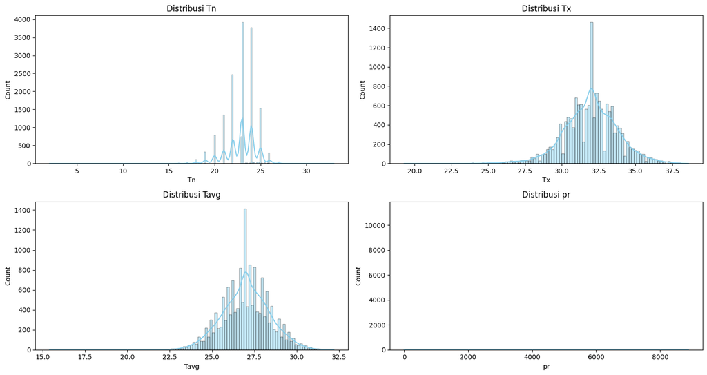

```python
import pandas as pd
    import matplotlib.pyplot as plt
    import seaborn as sns

    # Membaca dataset yang sudah dibersihkan
    cleaned_file_path = "https://raw.githubusercontent.com/Auliyaaas/Proyek-Sains-Data/main/PSD/Iklim%20Harian/iklim_harian_cleaned.csv"
    data_cleaned = pd.read_csv(cleaned_file_path)

    # Kolom numerik dalam dataset iklim_harian_cleaned
    kolom_numerik = ['Tn', 'Tx', 'Tavg', 'pr']

    # Menyiapkan plot
    plt.figure(figsize=(15, 8))

    # Loop untuk menampilkan distribusi dari setiap kolom numerik
    for i, kolom in enumerate(kolom_numerik):
        plt.subplot(2, 2, i+1)  # Mengatur posisi subplot
        sns.histplot(data_cleaned[kolom], kde=True, color='skyblue')  # Plot distribusi dengan kernel density estimate (KDE)
        plt.title(f'Distribusi {kolom}')  # Memberi judul pada setiap subplot

    # Menyusun layout agar tidak saling tumpang tindih
    plt.tight_layout()
    plt.show()
```

```python
import numpy as np  # Import library numpy
    import pandas as pd  # Import library pandas
    # Membaca file CSV dari GitHub
    url = "https://raw.githubusercontent.com/Auliyaaas/Proyek-Sains-Data/main/PSD/Iklim%20Harian/iklim_harian_cleaned.csv"
    df = pd.read_csv(url)  # Membaca file CSV dari URL dan menyimpannya ke dalam DataFrame df
    # Menampilkan ringkasan statistik hanya untuk data numerik
    df.describe()
```

|  | Tn | Tx | Tavg | pr |
| --- | --- | --- | --- | --- |
| count | 15706.000000 | 15706.000000 | 15706.000000 | 15706.000000 |
| mean | 22.916163 | 31.968434 | 27.013976 | 345.060053 |
| std | 1.583467 | 1.809332 | 1.388742 | 1705.643733 |
| min | 2.000000 | 19.300000 | 15.400000 | 0.000000 |
| 25% | 22.000000 | 30.900000 | 26.100000 | 0.000000 |
| 50% | 23.000000 | 31.984217 | 27.000000 | 0.000000 |
| 75% | 24.000000 | 33.100000 | 27.900000 | 2.000000 |
| max | 33.000000 | 38.600000 | 32.200000 | 8888.000000 |

### Menentukan Outlier

```python
import pandas as pd

    # Membaca dataset
    cleaned_file_path = "https://raw.githubusercontent.com/Auliyaaas/Proyek-Sains-Data/main/PSD/Iklim%20Harian/iklim_harian_cleaned.csv"
    data_cleaned = pd.read_csv(cleaned_file_path)

    # Kolom numerik yang akan diperiksa untuk outlier
    kolom_numerik = ['Tn', 'Tx', 'Tavg', 'pr']

    # Fungsi untuk mendeteksi outlier menggunakan IQR
    def detect_outliers_iqr(df, columns):
        outliers = {}
        for col in columns:
            Q1 = df[col].quantile(0.25)
            Q3 = df[col].quantile(0.75)
            IQR = Q3 - Q1
            lower_bound = Q1 - 1.5 * IQR
            upper_bound = Q3 + 1.5 * IQR

            # Menemukan outlier
            outliers[col] = df[(df[col] < lower_bound) | (df[col] > upper_bound)]
        return outliers

    # Mendapatkan outlier untuk kolom numerik
    outliers_iqr = detect_outliers_iqr(data_cleaned, kolom_numerik)

    # Menampilkan outlier untuk setiap kolom
    for kolom, outlier_data in outliers_iqr.items():
        print(f'Outliers untuk kolom {kolom}:')
        print(outlier_data[['tanggal', kolom]])  # Menampilkan tanggal dan nilai outlier
        print(f'Jumlah outlier: {len(outlier_data)}\n')
```

```
Outliers untuk kolom Tn:
              tanggal    Tn
    197    17-07-1978  17.0
    230    19-08-1978  18.0
    920    09-07-1980  18.0
    938    27-07-1980  18.0
    939    28-07-1980  18.0
    ...           ...   ...
    15179  24-07-2019  18.0
    15211  25-08-2019  18.0
    15219  02-09-2019  18.0
    15226  09-09-2019  16.0
    15378  08-02-2020  27.1

    [164 rows x 2 columns]
    Jumlah outlier: 164

    Outliers untuk kolom Tx:
              tanggal    Tx
    24     25-01-1978  27.2
    56     26-02-1978  24.0
    57     27-02-1978  25.0
    194    14-07-1978  26.4
    362    29-12-1978  26.6
    ...           ...   ...
    14998  24-01-2019  36.7
    15648  04-11-2020  36.7
    15660  16-11-2020  38.3
    15661  17-11-2020  37.0
    15664  20-11-2020  37.2

    [348 rows x 2 columns]
    Jumlah outlier: 348

    Outliers untuk kolom Tavg:
              tanggal  Tavg
    56     26-02-1978  23.2
    57     27-02-1978  23.0
    197    17-07-1978  22.6
    198    18-07-1978  22.7
```

[output cut: 12 more lines]

```
              tanggal    pr
    1      02-01-1978   8.0
    2      03-01-1978  26.0
    3      04-01-1978  21.0
    5      06-01-1978   9.0
    7      08-01-1978  17.0
    ...           ...   ...
    15692  18-12-2020  49.9
    15693  19-12-2020  15.6
    15694  20-12-2020  27.9
    15695  21-12-2020  44.7
    15697  23-12-2020  35.4

    [3111 rows x 2 columns]
    Jumlah outlier: 3111
```

### Menghapus Outlier

Meberadaan outlier dapat mempengaruhi hasil analisis data, sehingga perlu untuk dilakukan deteksi dan penghapusan outlier. Berikut merupakan program untuk menghapus outlier:

```python
import pandas as pd

    # Membaca dataset
    cleaned_file_path = "https://raw.githubusercontent.com/Auliyaaas/Proyek-Sains-Data/main/PSD/Iklim%20Harian/iklim_harian_cleaned.csv"
    data_cleaned = pd.read_csv(cleaned_file_path)

    # Kolom numerik yang akan diperiksa untuk outlier
    kolom_numerik = ['Tn', 'Tx', 'Tavg', 'pr']

    # Fungsi untuk menghapus outlier menggunakan IQR
    def remove_outliers_iqr(df, columns):
        for col in columns:
            Q1 = df[col].quantile(0.25)
            Q3 = df[col].quantile(0.75)
            IQR = Q3 - Q1
            lower_bound = Q1 - 1.5 * IQR
            upper_bound = Q3 + 1.5 * IQR

            # Menghapus baris yang merupakan outlier
            df = df[(df[col] >= lower_bound) & (df[col] <= upper_bound)]
        return df

    # Menghapus outlier untuk kolom numerik
    data_cleaned_no_outliers = remove_outliers_iqr(data_cleaned, kolom_numerik)

    # Menampilkan dataset setelah menghapus outlier
    data_cleaned_no_outliers.head()
```

|  | tanggal | Tn | Tx | Tavg | pr |
| --- | --- | --- | --- | --- | --- |
| 0 | 01-01-1978 | 24.0 | 32.4 | 28.3 | 0.0 |
| 4 | 05-01-1978 | 25.0 | 30.6 | 27.2 | 1.0 |
| 6 | 07-01-1978 | 25.0 | 30.4 | 28.1 | 0.0 |
| 10 | 11-01-1978 | 25.0 | 31.3 | 26.9 | 0.0 |
| 11 | 12-01-1978 | 24.0 | 31.0 | 25.9 | 0.0 |

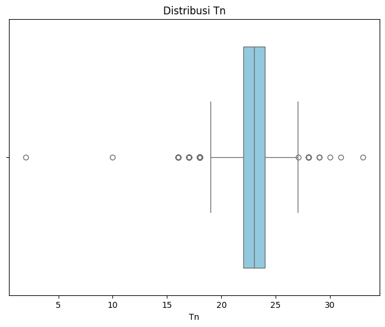

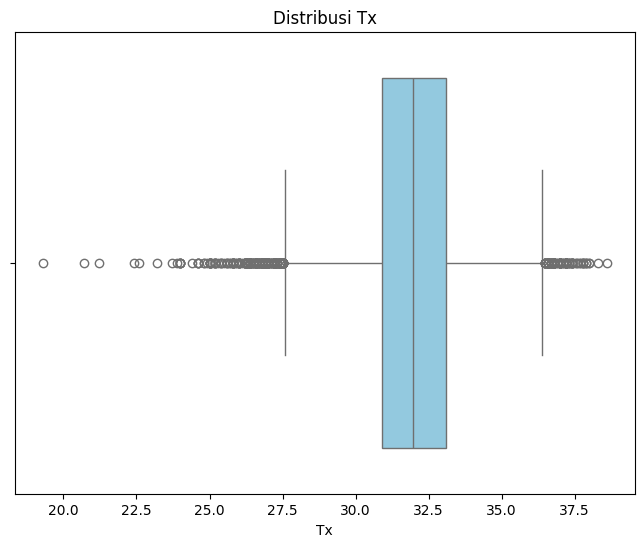

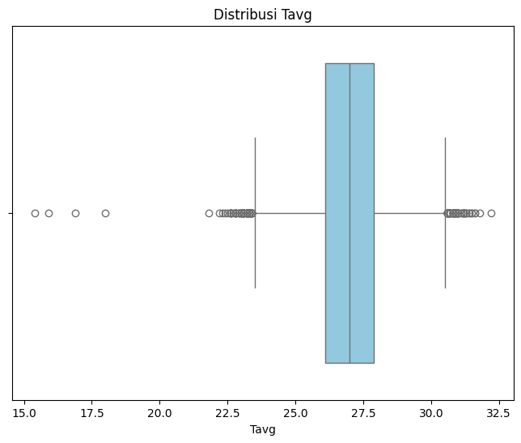

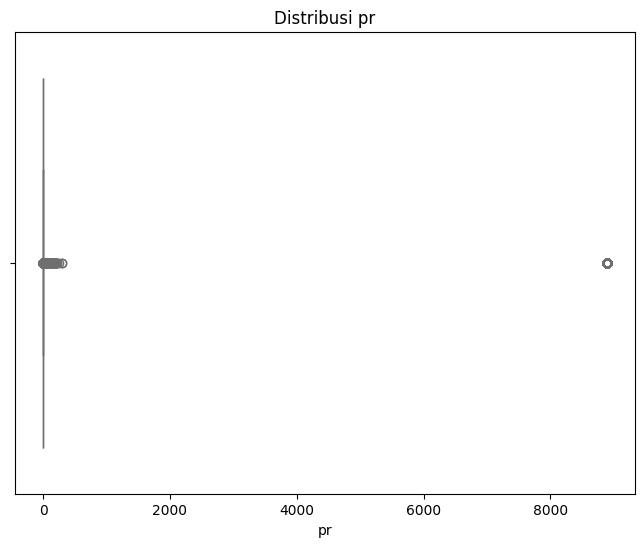

```python
import seaborn as sns
    import matplotlib.pyplot as plt

    # Kolom numerik pada dataset iklim_harian_cleaned
    kolom_numerik = ['Tn', 'Tx', 'Tavg', 'pr']

    # Menampilkan boxplot untuk setiap kolom numerik
    for kolom in kolom_numerik:
        plt.figure(figsize=(8, 6))  # Mengatur ukuran plot
        sns.boxplot(x=data_cleaned[kolom], color='skyblue')  # Menampilkan boxplot
        plt.title(f"Distribusi {kolom}")  # Judul untuk setiap boxplot
        plt.xlabel(kolom)  # Label untuk sumbu x
        plt.show()
```

### Visualisasi

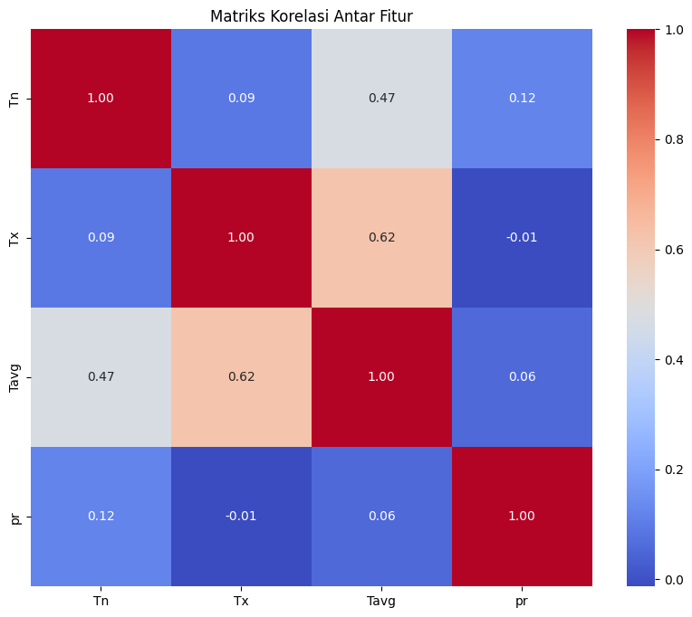

```python
import seaborn as sns
    import matplotlib.pyplot as plt

    # Kolom numerik pada dataset iklim_harian_cleaned
    kolom_numerik = ['Tn', 'Tx', 'Tavg', 'pr']

    # Menghitung korelasi antar fitur
    plt.figure(figsize=(10, 8))  # Ukuran plot
    sns.heatmap(data_cleaned[kolom_numerik].corr(), annot=True, cmap='coolwarm', fmt='.2f')  # Menampilkan heatmap
    plt.title("Matriks Korelasi Antar Fitur")  # Judul heatmap
    plt.show()
```

Melakukan pemisahan dataset menjadi raining set dan test set dengan proporsi 80% untuk pelatihan dan 20% untuk melakukan pengujian

```python
import pandas as pd
    from sklearn.model_selection import train_test_split

    # Membaca dataset yang sudah dibersihkan
    cleaned_file_path = "https://raw.githubusercontent.com/Auliyaaas/Proyek-Sains-Data/main/PSD/Iklim%20Harian/iklim_harian_cleaned.csv"
    data_cleaned = pd.read_csv(cleaned_file_path)

    # Kolom numerik yang akan digunakan sebagai fitur
    kolom_numerik = ['Tn', 'Tx', 'Tavg', 'pr']

    # Menentukan target variabel (misalnya, kita prediksi suhu rata-rata harian Tavg)
    target = 'Tavg'

    # Memisahkan fitur dan target
    X = data_cleaned[kolom_numerik].drop(columns=[target])  # Fitur
    y = data_cleaned[target]  # Target

    # Membagi data menjadi training dan testing set (80% untuk pelatihan, 20% untuk pengujian)
    X_train, X_test, y_train, y_test = train_test_split(X, y, test_size=0.2, random_state=42)

    # Menampilkan ukuran dataset setelah pemisahan
    print(f"Ukuran data training: {X_train.shape[0]} baris")
    print(f"Ukuran data testing: {X_test.shape[0]} baris")
```

```
Ukuran data training: 12564 baris
    Ukuran data testing: 3142 baris
```

Diperoleh data Ukuran data training: **12564** baris dan Ukuran data testing: **3142** baris

### Pemodelan

```python
import pandas as pd
    from sklearn.model_selection import train_test_split
    from sklearn.svm import SVR
    from sklearn.metrics import mean_absolute_error, mean_squared_error, r2_score
    from sklearn.preprocessing import StandardScaler

    # Membaca dataset yang sudah dibersihkan
    cleaned_file_path = "https://raw.githubusercontent.com/Auliyaaas/Proyek-Sains-Data/main/PSD/Iklim%20Harian/iklim_harian_cleaned.csv"
    data_cleaned = pd.read_csv(cleaned_file_path)

    # Kolom numerik yang akan digunakan sebagai fitur
    kolom_numerik = ['Tn', 'Tx', 'Tavg', 'pr']

    # Menentukan target variabel (misalnya, kita prediksi suhu rata-rata harian Tavg)
    target = 'Tavg'

    # Memisahkan fitur dan target
    X = data_cleaned[kolom_numerik].drop(columns=[target])  # Fitur
    y = data_cleaned[target]  # Target

    # Membagi data menjadi training dan testing set
    X_train, X_test, y_train, y_test = train_test_split(X, y, test_size=0.2, random_state=42)

    # Normalisasi data (SVR sangat dipengaruhi oleh skala data)
    scaler = StandardScaler()
    X_train_scaled = scaler.fit_transform(X_train)
    X_test_scaled = scaler.transform(X_test)

    # Inisialisasi model SVR
    svr = SVR(kernel='rbf')  # Menggunakan kernel Radial Basis Function (RBF)

    # Melatih model
    svr.fit(X_train_scaled, y_train)

    # Melakukan prediksi
    y_pred = svr.predict(X_test_scaled)

    # Menghitung metrik evaluasi
    mae = mean_absolute_error(y_test, y_pred)
    mse = mean_squared_error(y_test, y_pred)
    r2 = r2_score(y_test, y_pred)

    # Menampilkan hasil metrik
    print(f"Mean Absolute Error (MAE): {mae:.4f}")
    print(f"Mean Squared Error (MSE): {mse:.4f}")
    print(f"R² Score: {r2:.4f}")
```

```
Mean Absolute Error (MAE): 0.6999
    Mean Squared Error (MSE): 0.8362
    R² Score: 0.5461
```

```python
import pandas as pd
    from sklearn.model_selection import train_test_split
    from sklearn.linear_model import LinearRegression
    from sklearn.metrics import mean_absolute_error, mean_squared_error, r2_score
    from sklearn.preprocessing import StandardScaler

    # Membaca dataset yang sudah dibersihkan
    cleaned_file_path = "https://raw.githubusercontent.com/Auliyaaas/Proyek-Sains-Data/main/PSD/Iklim%20Harian/iklim_harian_cleaned.csv"
    data_cleaned = pd.read_csv(cleaned_file_path)

    # Kolom numerik yang akan digunakan sebagai fitur
    kolom_numerik = ['Tn', 'Tx', 'Tavg', 'pr']

    # Menentukan target variabel (misalnya, kita prediksi suhu rata-rata harian Tavg)
    target = 'Tavg'

    # Memisahkan fitur dan target
    X = data_cleaned[kolom_numerik].drop(columns=[target])  # Fitur
    y = data_cleaned[target]  # Target

    # Membagi data menjadi training dan testing set (80% untuk pelatihan, 20% untuk pengujian)
    X_train, X_test, y_train, y_test = train_test_split(X, y, test_size=0.2, random_state=42)

    # Normalisasi data (regresi linier sensitif terhadap skala data)
    scaler = StandardScaler()
    X_train_scaled = scaler.fit_transform(X_train)
    X_test_scaled = scaler.transform(X_test)

    # Inisialisasi model Linear Regression
    lin_reg = LinearRegression()

    # Melatih model
    lin_reg.fit(X_train_scaled, y_train)

    # Melakukan prediksi
    y_pred = lin_reg.predict(X_test_scaled)

    # Menghitung metrik evaluasi
    mae = mean_absolute_error(y_test, y_pred)
    mse = mean_squared_error(y_test, y_pred)
    r2 = r2_score(y_test, y_pred)

    # Menampilkan hasil metrik
    print(f"Mean Absolute Error (MAE): {mae:.4f}")
    print(f"Mean Squared Error (MSE): {mse:.4f}")
    print(f"R² Score: {r2:.4f}")
```

```
Mean Absolute Error (MAE): 0.7063
    Mean Squared Error (MSE): 0.8654
    R² Score: 0.5302
```

```python
import pandas as pd
    from sklearn.model_selection import train_test_split
    from sklearn.ensemble import RandomForestRegressor
    from sklearn.metrics import mean_absolute_error, mean_squared_error, r2_score
    from sklearn.preprocessing import StandardScaler

    # Membaca dataset yang sudah dibersihkan
    cleaned_file_path = "https://raw.githubusercontent.com/Auliyaaas/Proyek-Sains-Data/main/PSD/Iklim%20Harian/iklim_harian_cleaned.csv"
    data_cleaned = pd.read_csv(cleaned_file_path)

    # Kolom numerik yang akan digunakan sebagai fitur
    kolom_numerik = ['Tn', 'Tx', 'Tavg', 'pr']

    # Menentukan target variabel (misalnya, kita prediksi suhu rata-rata harian Tavg)
    target = 'Tavg'

    # Memisahkan fitur dan target
    X = data_cleaned[kolom_numerik].drop(columns=[target])  # Fitur
    y = data_cleaned[target]  # Target

    # Membagi data menjadi training dan testing set (80% untuk pelatihan, 20% untuk pengujian)
    X_train, X_test, y_train, y_test = train_test_split(X, y, test_size=0.2, random_state=42)

    # Normalisasi data (Random Forest tidak terlalu sensitif terhadap skala, tapi kita tetap lakukan untuk konsistensi)
    scaler = StandardScaler()
    X_train_scaled = scaler.fit_transform(X_train)
    X_test_scaled = scaler.transform(X_test)

    # Inisialisasi model Random Forest Regressor
    rf_regressor = RandomForestRegressor(n_estimators=100, random_state=42)

    # Melatih model
    rf_regressor.fit(X_train_scaled, y_train)

    # Melakukan prediksi
    y_pred = rf_regressor.predict(X_test_scaled)

    # Menghitung metrik evaluasi
    mae = mean_absolute_error(y_test, y_pred)
    mse = mean_squared_error(y_test, y_pred)
    r2 = r2_score(y_test, y_pred)

    # Menampilkan hasil metrik
    print(f"Mean Absolute Error (MAE): {mae:.4f}")
    print(f"Mean Squared Error (MSE): {mse:.4f}")
    print(f"R² Score: {r2:.4f}")
```

```
Mean Absolute Error (MAE): 0.7184
    Mean Squared Error (MSE): 0.9015
    R² Score: 0.5106
```

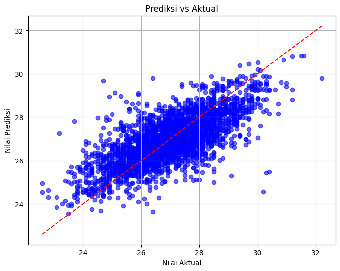

```python
import matplotlib.pyplot as plt

    # Membuat plot scatter untuk membandingkan prediksi dan nilai aktual
    plt.figure(figsize=(8, 6))
    plt.scatter(y_test, y_pred, color='blue', alpha=0.6)
    plt.plot([y_test.min(), y_test.max()], [y_test.min(), y_test.max()], color='red', linestyle='--')  # Garis diagonal
    plt.title("Prediksi vs Aktual")
    plt.xlabel("Nilai Aktual")
    plt.ylabel("Nilai Prediksi")
    plt.grid(True)
    plt.show()
```

```python
import pandas as pd
    from sklearn.model_selection import train_test_split
    from sklearn.linear_model import LinearRegression
    from sklearn.metrics import mean_absolute_error, mean_squared_error, r2_score
    from sklearn.preprocessing import StandardScaler
    import numpy as np

    # Membaca dataset yang sudah dibersihkan
    cleaned_file_path = "https://raw.githubusercontent.com/Auliyaaas/Proyek-Sains-Data/main/PSD/Iklim%20Harian/iklim_harian_cleaned.csv"
    data_cleaned = pd.read_csv(cleaned_file_path)

    # Menentukan fitur dan target
    kolom_numerik = ['Tn', 'Tx', 'Tavg', 'pr']
    target = 'Tavg'

    # Menambahkan kolom target untuk hari berikutnya
    data_cleaned['Tavg_next_day'] = data_cleaned['Tavg'].shift(-1)

    # Menghapus baris terakhir yang tidak memiliki nilai target
    data_cleaned.dropna(inplace=True)

    # Memisahkan fitur (X) dan target (y)
    X = data_cleaned[kolom_numerik]
    y = data_cleaned['Tavg_next_day']

    # Membagi data menjadi training dan testing set (80% untuk pelatihan, 20% untuk pengujian)
    X_train, X_test, y_train, y_test = train_test_split(X, y, test_size=0.2, random_state=42)

    # Normalisasi data
    scaler = StandardScaler()
    X_train_scaled = scaler.fit_transform(X_train)
    X_test_scaled = scaler.transform(X_test)

    # Inisialisasi model regresi linier
    lin_reg = LinearRegression()

    # Melatih model
    lin_reg.fit(X_train_scaled, y_train)

    # Melakukan prediksi pada data uji
    y_pred = lin_reg.predict(X_test_scaled)

    # Menghitung metrik evaluasi
    mae = mean_absolute_error(y_test, y_pred)
    mse = mean_squared_error(y_test, y_pred)
    r2 = r2_score(y_test, y_pred)

    # Menampilkan metrik evaluasi
    print(f"Mean Absolute Error (MAE): {mae:.4f}")
    print(f"Mean Squared Error (MSE): {mse:.4f}")
    print(f"R² Score: {r2:.4f}")

    # Prediksi cuaca pada hari berikutnya untuk data terbaru
    latest_features = X.iloc[-1].values.reshape(1, -1)  # Fitur dari hari terakhir
    latest_features_scaled = scaler.transform(latest_features)  # Normalisasi
    prediksi_hari_berikutnya = lin_reg.predict(latest_features_scaled)

    print(f"Prediksi cuaca (Tavg) untuk hari berikutnya: {prediksi_hari_berikutnya[0]:.2f}")
```

```
Mean Absolute Error (MAE): 0.6829
    Mean Squared Error (MSE): 0.8053
    R² Score: 0.5614
    Prediksi cuaca (Tavg) untuk hari berikutnya: 27.30
```

```python
import pandas as pd
    from sklearn.model_selection import train_test_split
    from sklearn.multioutput import MultiOutputRegressor
    from sklearn.linear_model import LinearRegression
    from sklearn.metrics import mean_absolute_error, mean_squared_error, r2_score
    from sklearn.preprocessing import StandardScaler
    import numpy as np

    # Membaca dataset yang sudah dibersihkan
    cleaned_file_path = "https://raw.githubusercontent.com/Auliyaaas/Proyek-Sains-Data/main/PSD/Iklim%20Harian/iklim_harian_cleaned.csv"
    data_cleaned = pd.read_csv(cleaned_file_path)

    # Menambahkan kolom target untuk setiap fitur untuk hari berikutnya
    data_cleaned['Tn_next_day'] = data_cleaned['Tn'].shift(-1)
    data_cleaned['Tx_next_day'] = data_cleaned['Tx'].shift(-1)
    data_cleaned['Tavg_next_day'] = data_cleaned['Tavg'].shift(-1)
    data_cleaned['Pr_next_day'] = data_cleaned['pr'].shift(-1)

    # Menghapus baris terakhir yang tidak memiliki nilai target
    data_cleaned.dropna(inplace=True)

    # Menentukan fitur dan target
    kolom_fitur = ['Tn', 'Tx', 'Tavg', 'pr']
    kolom_target = ['Tn_next_day', 'Tx_next_day', 'Tavg_next_day', 'Pr_next_day']

    X = data_cleaned[kolom_fitur]  # Fitur
    y = data_cleaned[kolom_target]  # Target

    # Membagi data menjadi training dan testing set (80% untuk pelatihan, 20% untuk pengujian)
    X_train, X_test, y_train, y_test = train_test_split(X, y, test_size=0.2, random_state=42)

    # Normalisasi data
    scaler = StandardScaler()
    X_train_scaled = scaler.fit_transform(X_train)
    X_test_scaled = scaler.transform(X_test)

    # Inisialisasi model regresi linier multi-output
    lin_reg = MultiOutputRegressor(LinearRegression())

    # Melatih model
    lin_reg.fit(X_train_scaled, y_train)

    # Melakukan prediksi pada data uji
    y_pred = lin_reg.predict(X_test_scaled)

    # Evaluasi model untuk setiap target
    mae = mean_absolute_error(y_test, y_pred, multioutput='raw_values')
    mse = mean_squared_error(y_test, y_pred, multioutput='raw_values')
    r2 = r2_score(y_test, y_pred, multioutput='raw_values')

    # Menampilkan metrik evaluasi untuk setiap target
    print("Evaluasi Model:")
    for i, target in enumerate(kolom_target):
        print(f"{target}:")
        print(f"  Mean Absolute Error (MAE): {mae[i]:.4f}")
        print(f"  Mean Squared Error (MSE): {mse[i]:.4f}")
        print(f"  R² Score: {r2[i]:.4f}")
        print()

    # Prediksi untuk hari berikutnya berdasarkan data terbaru
    latest_features = X.iloc[-1].values.reshape(1, -1)  # Fitur dari hari terakhir
    latest_features_scaled = scaler.transform(latest_features)  # Normalisasi
    prediksi_hari_berikutnya = lin_reg.predict(latest_features_scaled)

    # Menampilkan prediksi untuk hari berikutnya
    print("Prediksi Cuaca untuk Hari Berikutnya:")
    for i, target in enumerate(kolom_target):
        print(f"{target}: {prediksi_hari_berikutnya[0][i]:.2f}")
```

```
Evaluasi Model:
    Tn_next_day:
      Mean Absolute Error (MAE): 0.8963
      Mean Squared Error (MSE): 1.4145
      R² Score: 0.3901

    Tx_next_day:
      Mean Absolute Error (MAE): 0.8977
      Mean Squared Error (MSE): 1.6178
      R² Score: 0.5103

    Tavg_next_day:
      Mean Absolute Error (MAE): 0.6829
      Mean Squared Error (MSE): 0.8053
      R² Score: 0.5614

    Pr_next_day:
      Mean Absolute Error (MAE): 628.3195
      Mean Squared Error (MSE): 2628167.2002
      R² Score: 0.0146

    Prediksi Cuaca untuk Hari Berikutnya:
    Tn_next_day: 24.23
    Tx_next_day: 30.58
    Tavg_next_day: 27.30
    Pr_next_day: 580.85
```

### Kesimpulan

1. Support Vector Regression (SVR) MAE: 0.6999 MSE: 0.8362 R² Score: 0.5461 Model SVR menunjukkan performa terbaik dibandingkan model lainnya dengan nilai R² Score tertinggi, yaitu 0.5461. Hal ini menunjukkan bahwa SVR dapat menjelaskan sekitar 54.61% variabilitas data target. Nilai MAE dan MSE relatif lebih rendah dibandingkan dengan model lainnya, menunjukkan bahwa SVR cukup efektif dalam memprediksi nilai cuaca harian.
2. Random Forest MAE: 0.7184 MSE: 0.9015 R² Score: 0.5106 Model Random Forest memiliki performa yang cukup baik, tetapi sedikit di bawah SVR. R² Score sebesar 0.5106 menunjukkan bahwa model ini mampu menjelaskan sekitar 51.06% variabilitas data target. Nilai MAE dan MSE yang sedikit lebih tinggi dibandingkan dengan SVR menunjukkan bahwa model ini sedikit kurang presisi dibandingkan SVR.
3. Regresi Linier MAE: 0.7063 MSE: 0.8654 R² Score: 0.5302 Model regresi linier memberikan hasil yang berada di antara SVR dan Random Forest. Dengan R² Score sebesar 0.5302, model ini mampu menjelaskan sekitar 53.02% variabilitas data target. Nilai MAE dan MSE juga menunjukkan performa yang konsisten dan bersaing dengan model lainnya.

```python
import pandas as pd
    from sklearn.model_selection import train_test_split
    from sklearn.multioutput import MultiOutputRegressor
    from sklearn.linear_model import LinearRegression
    from sklearn.metrics import mean_absolute_error, mean_squared_error, r2_score
    from sklearn.preprocessing import StandardScaler
    import numpy as np

    # Membaca dataset yang sudah dibersihkan
    cleaned_file_path = "https://raw.githubusercontent.com/Auliyaaas/Proyek-Sains-Data/main/PSD/Iklim%20Harian/iklim_harian_cleaned.csv"
    data_cleaned = pd.read_csv(cleaned_file_path)

    # Menambahkan kolom target untuk setiap fitur untuk hari berikutnya
    data_cleaned['Tn_next_day'] = data_cleaned['Tn'].shift(-1)
    data_cleaned['Tx_next_day'] = data_cleaned['Tx'].shift(-1)
    data_cleaned['Tavg_next_day'] = data_cleaned['Tavg'].shift(-1)
    data_cleaned['Pr_next_day'] = data_cleaned['pr'].shift(-1)

    # Menghapus baris terakhir yang tidak memiliki nilai target
    data_cleaned.dropna(inplace=True)

    # Menentukan fitur dan target
    kolom_fitur = ['Tn', 'Tx', 'Tavg', 'pr']
    kolom_target = ['Tn_next_day', 'Tx_next_day', 'Tavg_next_day', 'Pr_next_day']

    X = data_cleaned[kolom_fitur]  # Fitur
    y = data_cleaned[kolom_target]  # Target

    # Membagi data menjadi training dan testing set (80% untuk pelatihan, 20% untuk pengujian)
    X_train, X_test, y_train, y_test = train_test_split(X, y, test_size=0.2, random_state=42)

    # Normalisasi data
    scaler = StandardScaler()
    X_train_scaled = scaler.fit_transform(X_train)
    X_test_scaled = scaler.transform(X_test)

    # Inisialisasi model regresi linier multi-output
    lin_reg = MultiOutputRegressor(LinearRegression())

    # Melatih model
    lin_reg.fit(X_train_scaled, y_train)

    # Melakukan prediksi pada data uji
    y_pred = lin_reg.predict(X_test_scaled)

    # Evaluasi model untuk setiap target
    mae = mean_absolute_error(y_test, y_pred, multioutput='raw_values')
    mse = mean_squared_error(y_test, y_pred, multioutput='raw_values')
    r2 = r2_score(y_test, y_pred, multioutput='raw_values')

    # Menampilkan metrik evaluasi untuk setiap target
    print("Evaluasi Model:")
    for i, target in enumerate(kolom_target):
        print(f"{target}:")
        print(f"  Mean Absolute Error (MAE): {mae[i]:.4f}")
        print(f"  Mean Squared Error (MSE): {mse[i]:.4f}")
        print(f"  R² Score: {r2[i]:.4f}")
        print()

    # Fungsi untuk menerima input dari pengguna dan melakukan prediksi
    def prediksi_manual():
        print("Masukkan data cuaca untuk prediksi hari berikutnya:")
        try:
            Tn = float(input("  Tn (Temperatur Minimum): "))
            Tx = float(input("  Tx (Temperatur Maksimum): "))
            Tavg = float(input("  Tavg (Temperatur Rata-rata): "))
            pr = float(input("  pr (Curah Hujan): "))

            # Membentuk array fitur berdasarkan input pengguna
            input_features = np.array([[Tn, Tx, Tavg, pr]])
            input_features_scaled = scaler.transform(input_features)  # Normalisasi

            # Melakukan prediksi
            prediksi = lin_reg.predict(input_features_scaled)

            # Menampilkan hasil prediksi
            print("\nPrediksi Cuaca untuk Hari Berikutnya:")
            for i, target in enumerate(kolom_target):
                print(f"{target}: {prediksi[0][i]:.2f}")
        except ValueError:
            print("\nInput tidak valid. Pastikan memasukkan angka untuk setiap fitur.")

    # Memanggil fungsi prediksi manual
    prediksi_manual()
```

```
Evaluasi Model:
    Tn_next_day:
      Mean Absolute Error (MAE): 0.8963
      Mean Squared Error (MSE): 1.4145
      R² Score: 0.3901

    Tx_next_day:
      Mean Absolute Error (MAE): 0.8977
      Mean Squared Error (MSE): 1.6178
      R² Score: 0.5103

    Tavg_next_day:
      Mean Absolute Error (MAE): 0.6829
      Mean Squared Error (MSE): 0.8053
      R² Score: 0.5614

    Pr_next_day:
      Mean Absolute Error (MAE): 628.3195
      Mean Squared Error (MSE): 2628167.2002
      R² Score: 0.0146

    Masukkan data cuaca untuk prediksi hari berikutnya:
      Tn (Temperatur Minimum): 24.2
      Tx (Temperatur Maksimum): 33.2
      Tavg (Temperatur Rata-rata): 28.3
      pr (Curah Hujan): 0.0

    Prediksi Cuaca untuk Hari Berikutnya:
    Tn_next_day: 23.82
    Tx_next_day: 32.92
    Tavg_next_day: 28.06
    Pr_next_day: 428.16
```